# P-values, Null distributions, Omics ranking

## Kolmogorov-Smirnov statistic

The idea for this statistic came from viewing this as a *gene enrichment* problem (see References).

- **KS test**: check if 2 data samples come from the same probability distribution or not. It uses the eCDF (Empirical Cumulative Density Function) [[wikipedia](https://en.wikipedia.org/wiki/Kolmogorov-Smirnov_test)]

Let’s view an example using the research results and consider the `Clinical` as the omic of interest:

```r
coxnet_scores = coxnet_scores %>%
  mutate(grp = case_when(
    grepl(pattern = 'Clinical', x = Task) ~ 'Clin',
    TRUE ~ 'not-Clin')
  )

clin     = coxnet_scores %>% filter(grp == 'Clin') %>% pull(Cindex)
not_clin = coxnet_scores %>% filter(grp == 'not-Clin') %>% pull(Cindex)
```

Histograms/Density of the performance scores (C-indexes), comparing omic-combos that had **Clinical** features included vs those that did not:

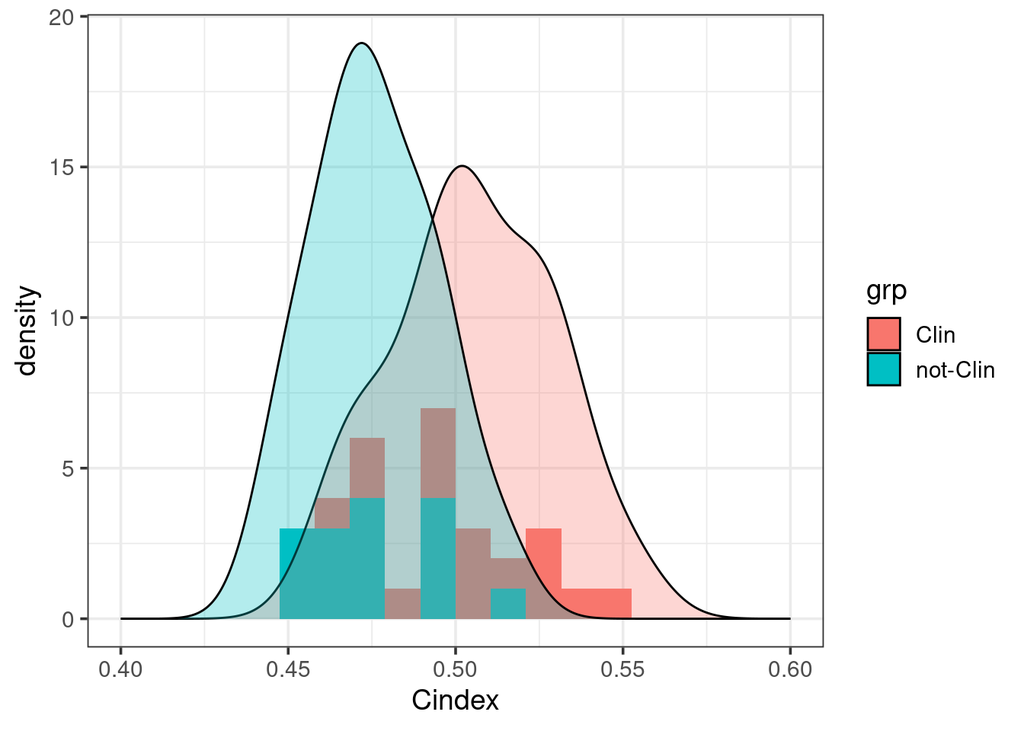

```r
ggplot(coxnet_scores, aes(y = Cindex, fill = grp)) +
  geom_histogram(bins = 20) +
  geom_density(alpha = 0.3) +
  ylim(c(0.4, 0.6)) +
  coord_flip() +
  theme_bw(base_size = 14)
```

The empirical Cumulative Distribution Function for each group is:

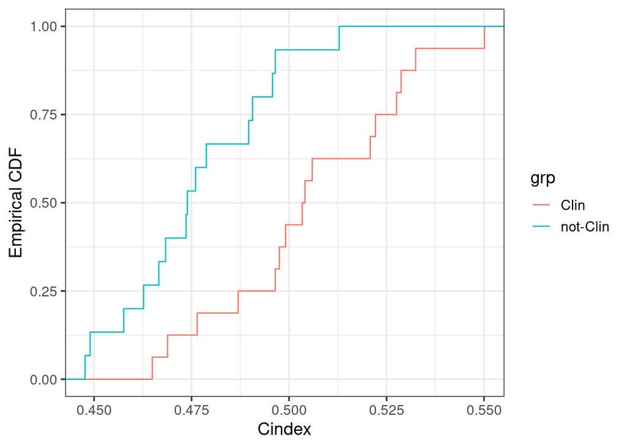

```r
ggplot(coxnet_scores, aes(Cindex, colour = grp)) +
  stat_ecdf() +
  labs(y = 'Empirical CDF') +
  theme_bw(base_size = 14)
```

```r
ks.test(x = clin, y = not_clin, alternative = 'less')
```

```
    Exact two-sample Kolmogorov-Smirnov test

data:  clin and not_clin
D^- = 0.62083, p-value = 0.0009361
alternative hypothesis: the CDF of x lies below that of y
```

Usually it’s better to not re-invent the wheel but sometimes we need to!

# References

- Chapter 13 of 2nd edition of *An Introduction to Statistical Learning*, Springer
- Subramanian, A., Tamayo, P., Mootha, V. K., Mukherjee, S., Ebert, B. L., Gillette, M. A., Paulovich, A., Pomeroy, S. L., Golub, T. R., Lander, E. S., & Mesirov, J. P. (2005). Gene set enrichment analysis: A knowledge-based approach for interpreting genome-wide expression profiles. Proceedings of the National Academy of Sciences, 102(43), 15545–15550. https://doi.org/10.1073/PNAS.0506580102